# Imports

```python
import matplotlib.pyplot as plt
import numpy as np
import pandas as pd
import pyreadr
import torch
import torch.nn as nn
import torch.optim as optim
from scipy.optimize import minimize
from sklearn.decomposition import PCA
from sklearn.metrics import silhouette_score
from sklearn.mixture import GaussianMixture
```

## Convert data files to csv

### Decathlon

```python
# Load RData file
rdata = pyreadr.read_r("data/decathlon.RData")
rdata
```

[output not shown]

[output cut: 33 more lines]

[output not shown]

```python
# Access the data frame from the loaded RData file
decathlon = rdata["X"]
decathlon.head()
```

| rownames | 100m | Long.jump | Shot.put | High.jump | 400m | 110m.hurdle | Discus | Pole.vault | Javeline | 1500m |
| --- | --- | --- | --- | --- | --- | --- | --- | --- | --- | --- |
| SEBRLE | 11.04 | 7.58 | 14.83 | 2.07 | 49.81 | 14.69 | 43.75 | 5.02 | 63.19 | 291.7 |
| CLAY | 10.76 | 7.40 | 14.26 | 1.86 | 49.37 | 14.05 | 50.72 | 4.92 | 60.15 | 301.5 |
| KARPOV | 11.02 | 7.30 | 14.77 | 2.04 | 48.37 | 14.09 | 48.95 | 4.92 | 50.31 | 300.2 |
| BERNARD | 11.02 | 7.23 | 14.25 | 1.92 | 48.93 | 14.99 | 40.87 | 5.32 | 62.77 | 280.1 |
| YURKOV | 11.34 | 7.09 | 15.19 | 2.10 | 50.42 | 15.31 | 46.26 | 4.72 | 63.44 | 276.4 |

```python
# Convert the data frame to a CSV file
decathlon.to_csv("data/decathlon.csv", index=True)
```

### Train and test datafiles

```python
train = {
    f"{letter}": pd.read_csv(
        f"data/train{letter}", delimiter=" ", names=["x1", "x2", "y"]
    )
    for letter in ["A", "B", "C"]
}
train["A"]
```

|  | x1 | x2 | y |
| --- | --- | --- | --- |
| 0 | 12.138367 | 6.455699 | 1 |
| 1 | 10.622594 | 11.083096 | 0 |
| 2 | 11.777052 | 8.121582 | 1 |
| 3 | 10.960882 | 12.226554 | 0 |
| 4 | 11.296539 | 10.211002 | 0 |
| ... | ... | ... | ... |
| 95 | 10.188695 | 6.171622 | 1 |
| 96 | 11.024072 | 4.082187 | 1 |
| 97 | 11.090619 | 10.954867 | 0 |
| 98 | 9.840793 | 4.902898 | 1 |
| 99 | 9.470945 | 8.945310 | 0 |

100 rows × 3 columns

```python
test = {
    f"{letter}": pd.read_csv(
        f"data/test{letter}", delimiter=" ", names=["x1", "x2", "y"]
    )
    for letter in ["A", "B", "C"]
}
test["A"]
```

|  | x1 | x2 | y |
| --- | --- | --- | --- |
| 0 | 12.356261 | 6.053231 | 1 |
| 1 | 11.842674 | 4.832690 | 1 |
| 2 | 12.080976 | 5.739803 | 1 |
| 3 | 9.435296 | 8.878012 | 0 |
| 4 | 11.023415 | 6.173500 | 1 |
| ... | ... | ... | ... |
| 95 | 12.132122 | 10.539799 | 0 |
| 96 | 10.948403 | 6.676466 | 1 |
| 97 | 8.728051 | 5.950333 | 1 |
| 98 | 9.376795 | 9.968496 | 0 |
| 99 | 10.647086 | 4.942951 | 1 |

100 rows × 3 columns

# 1- Classification

## 1.1 Analyse linéaire discriminante

### a- Ecrire l'estimateur du maximum de vraisemblance des paramètres du modèle

$$\begin{align*} L_{(x_i, y_i)_i}(\pi, \mu_0, \mu_1, \Sigma) & = log \hspace{8px} p(x_1,..., x_n, y_1,...y_n | \pi, \mu_0, \mu_1, \Sigma) \\ & = \sum_{i=1}^n log \hspace{8px} p(x_i, y_i | \pi, \mu_0, \mu_1, \Sigma) \\ & = \sum_{i=1}^n log \hspace{8px} p(x_i | y_i, \mu_0, \mu_1, \Sigma) * p(y_i | \pi) \\ & = \sum_{i=1}^n log \hspace{8px} p(x_i | y_i, \mu_0, \mu_1, \Sigma) + \sum_{i=1}^n log \hspace{8px} p(y_i | \pi) \end{align*}$$

On remarque qu'en dérivant par rapport à $\pi$ dans (4), on perdra la somme de gauche.  
De même, en dérivant par rapport à $\mu_0, \mu_1$ ou $\Sigma$, on perdra la somme de droite.  
On va donc calculer $\hat{\pi}_{EMV}$ et $\hat{\mu_0}_{EMV}$, $\hat{\mu_1}_{EMV}$, $\hat{\Sigma}_{EMV}$ à part.

**Commençons par calculer $\hat{\pi}_{EMV}$**

$$\begin{align*} L_{(y_i)_i}(\pi) & = log \hspace{8px} p(y_1,...y_n | \pi) \\ & = \sum_{i=1}^n log \hspace{8px} p(y_i | \pi) \\ & = \sum_{i=1}^n log \hspace{8px} \pi^{y_i} \cdot (1-\pi)^{1-y_i} \\ & = \sum_{i=1}^n y_i \cdot log(\pi) + (1-y_i) \cdot log(1-\pi) \\ \end{align*}$$

Dérivons cette quantité par rapport à $\pi$

$$\begin{align*} \nabla_\pi(L_{(y_i)_i}(\pi)) & = \sum_{i=1}^n \frac{y_i}{\pi} - \frac{1}{1-\pi} + \frac{y_i}{1-\pi} \\ & = - \frac{n}{1-\pi} + \sum_{i=1}^n \frac{y_i}{\pi(1-\pi)} \end{align*}$$

Maximiser la vraisemblance revient à maximiser la log-vraisemblance par croissance de la fonction logarithme sur $[0, 1]$, l'ensemble de définition de $\pi$.  
Déterminons la valeur de $\pi$ qui maximise la log-vraisemblance.

Soit $\pi \in [0, 1] / \nabla_\pi(L_{(y_i)_i}(\pi)) = 0$, alors on a $$ \sum_{i=1}^n \frac{y_i}{\pi(1-\pi)} = \frac{n}{1-\pi} $$ i.e. $$ \pi = \frac{1}{n} \sum_{i=1}^{n} y_i = \bar{y}$$

Donc $\boxed{\hat{\pi}_{EMV} = \bar{y}}$

**A présent, calculons $\hat{\mu_0}, \hat{\mu_1}$ et $\hat{\Sigma}$**

$$ \begin{align*} L_{(x_i)_i}(y_i, \mu_0, \mu_1, \Sigma) & = \log p(x_1, \ldots, x_n | y_1, \ldots, y_n, \mu_0, \mu_1, \Sigma) \\ & = \sum_{i=1}^n \log p(x_i | y_i, \mu_0, \mu_1, \Sigma) \\ & = \sum_{i=1}^n \left[ \mathbb{1}_{y_i = 0} \cdot \log \left( \frac{1}{\sqrt{(2\pi)^2 |\Sigma|}} \exp\left( -\frac{1}{2} (x_i - \mu_0)^T \Sigma^{-1} (x_i - \mu_0) \right) \right) \right. \\ & \quad \left. + \mathbb{1}_{y_i = 1} \cdot \log \left( \frac{1}{\sqrt{(2\pi)^2 |\Sigma|}} \exp\left( -\frac{1}{2} (x_i - \mu_1)^T \Sigma^{-1} (x_i - \mu_1) \right) \right) \right] \\ & = \sum_{i=1}^n \left[ \mathbb{1}_{y_i = 0} \cdot \left( - \log(2\pi) - \frac{1}{2} \log|\Sigma| - \frac{1}{2} (x_i - \mu_0)^T \Sigma^{-1} (x_i - \mu_0) \right) \right. \\ & \quad \left. + \mathbb{1}_{y_i = 1} \cdot \left( - \log(2\pi) - \frac{1}{2} \log|\Sigma| - \frac{1}{2} (x_i - \mu_1)^T \Sigma^{-1} (x_i - \mu_1) \right) \right] \end{align*} $$

On peut calculer, à partir de cette forme, le gradient de la log vraisemblance par rapport à $\mu_0$.

$$ \nabla_{\mu_0}(L_{(x_i)_i}(y_i, \mu_0, \mu_1, \Sigma)) = - \sum_{i=1}^{n} \mathbb{1}_{y_i = 0} \cdot \Sigma^{-1} \cdot (x_i - \mu_0) $$

Et alors, on peut maximiser la log vraisemblance.  
Soit $\mu_0 \in \mathbb{R}^2 / \nabla_{\mu_0}(L_{(x_i)_i}(y_i, \mu_0, \mu_1, \Sigma)) = 0_2$, on a alors

$$ - \sum_{i=1}^{n} \mathbb{1}_{y_i = 0} \cdot ( \Sigma^{-1} \cdot x_i - \Sigma^{-1} \cdot \mu_0 ) = 0 $$

Introduisons les notations $n_0 = card\{i \in [1;n] / y_i = 0\}$, le nombre d'individus dans la classe 0,  
et $\bar{x_0} = \sum_{i=1}^{n} \mathbb{1}_{y_i = 0} \cdot x_i$, la moyenne des individus de la classe 0.

On a alors $$ n_0 \cdot \Sigma^{-1} \mu_0 = \Sigma^{-1} \cdot \sum_{i=1}^{n} \mathbb{1}_{y_i = 0} \cdot x_i $$

Et donc $$ \boxed{\mu_0 = \hat{\mu_0} = \frac{\bar{x_0}}{n_0}} $$

De la même façon, on calcule $\boxed{\displaystyle \hat{\mu_1} = \frac{\bar{x_1}}{n_1}}$

**Calcul de $\hat{\Sigma}$ :**  
On sait que $\displaystyle \hat{\Sigma_{EMV}} = \sum_{i=1}^{n} (x_i - \hat{\mu_{EMV}}) \cdot (x_i - \hat{\mu_{EMV}})^T$ pour un vecteur aléatoire gaussien.

Dans notre cas à deux classes,

$$\hat{\Sigma_{EMV}} = \frac{ \sum_{i=1}^{n} \mathbb{1}_{y_i = 0} (x_i - \hat{\mu_0}) \cdot (x_i - \hat{\mu_0})^T + \sum_{i=1}^{n} \mathbb{1}_{y_i = 1} (x_i - \hat{\mu_1}) \cdot (x_i - \hat{\mu_1})^T }{ n } $$

**Justification :**  
En réutilisant la preuve du cours,

$$ \begin{align*} \nabla_{\Sigma}(L_{(x_i)_i}(y_i, \mu_0, \mu_1, \Sigma)) = &- \frac{n_0}{2}\Sigma^{-1} + \frac{1}{2}\Sigma^{-1} \cdot \sum_{i=1}^{n} \mathbb{1}_{y_i = 0} (x_i - \mu_0) \cdot (x_i - \mu_0)^T \cdot \Sigma^{-1} \\ &- \frac{n_1}{2}\Sigma^{-1} + \frac{1}{2}\Sigma^{-1} \cdot \sum_{i=1}^{n} \mathbb{1}_{y_i = 1} (x_i - \mu_1) \cdot (x_i - \mu_1)^T \cdot \Sigma^{-1} \end{align*}$$

On peut alors maximiser la vraisemblance :

$$\Leftrightarrow 0_{(2,2)} = \nabla_{\Sigma}(L_{(x_i)_i}(y_i, \mu_0, \mu_1, \Sigma)) $$$$\Leftrightarrow \begin{align*} 0 = &- \frac{n_0}{2}\Sigma + \frac{1}{2} \sum_{i=1}^{n} \mathbb{1}_{y_i = 0} (x_i - \mu_0) \cdot (x_i - \mu_0)^T \\ &- \frac{n_1}{2}\Sigma + \frac{1}{2} \sum_{i=1}^{n} \mathbb{1}_{y_i = 1} (x_i - \mu_1) \cdot (x_i - \mu_1)^T \end{align*} $$$$\Leftrightarrow 0 = -\frac{n_0 + n_1}{2} \cdot \Sigma + \frac{1}{2} \cdot \sum_{i=1}^{n} \mathbb{1}_{y_i = 0} \cdot (x_i - \mu_0) \cdot (x_i - \mu_0)^T + \mathbb{1}_{y_i = 1} (x_i - \mu_1) \cdot (x_i - \mu_1)^T $$$$\Leftrightarrow \boxed{ \Sigma = \frac{ \sum_{i=1}^{n} \mathbb{1}_{y_i = 0} \cdot (x_i - \mu_0) \cdot (x_i - \mu_0)^T + \mathbb{1}_{y_i = 1} (x_i - \mu_1) \cdot (x_i - \mu_1)^T }{ n_0 + n_1 } } $$

### b- Donner la probabilité conditionnelle $P(Y=1|X=x)$. Comparer avec la même quantité dans le cadre de la régression logistique

On rappel que l'on note $p(x|\theta)$ la fonction de densité de la loi marginale de $X$ de paramètre $\theta$ évaluée en $x$. $$\begin{align*} P(Y=1 | X=x) &= \frac{p(x | y=1, \theta) \cdot p(y=1|\pi)}{p(x | \theta)} \\ &= \frac{\mathcal{N}(x ; \mu_1, \Sigma) \cdot \pi}{p(x | \theta)} \\ \end{align*} $$ Par renversement du conditionnement avec la formule de Bayes.

On peut calculer la loi marginale de $X$ au dénominateur :

$$ \begin{align*} p(x | \theta) =& \mathcal{N}(x ; \mu_0, \Sigma) \cdot p(y=0|\pi) + \mathcal{N}(x ; \mu_1, \Sigma) \cdot p(y=1|\pi) \\ =& \frac{1}{\sqrt{2\pi^{2}|\Sigma|}} \cdot e^{-\frac{1}{2} (x - \mu_0)^T \Sigma^{-1} (x - \mu_0)} \cdot (1-\pi) + \frac{1}{\sqrt{2\pi^{2}|\Sigma|}} \cdot e^{-\frac{1}{2} (x - \mu_1)^T \Sigma^{-1} (x - \mu_1)} \cdot \pi \end{align*} $$

$X$ est un mélange de gaussiennes de même matrices de variances covariances et de moyennes différentes.

Développons la formule.

$$\begin{align*} P(Y=1 | X=x) &= \frac{ \mathcal{N}(x ; \mu_1, \Sigma) \cdot \pi }{ \mathcal{N}(x ; \mu_0, \Sigma) \cdot (1-\pi) + \mathcal{N}(x ; \mu_1, \Sigma) \cdot \pi } \\ &= \frac{1}{ 1 + \frac{ \mathcal{N}(x ; \mu_0, \Sigma) \cdot (1-\pi) }{ \mathcal{N}(x ; \mu_1, \Sigma) \cdot \pi } } \hspace{10px} \text{en factorisant par $\mathcal{N}(x ; \mu_1, \Sigma) \cdot \pi$ et en supposant que $\pi \ne 0$} \\ &= \frac{1}{ 1 + \frac{1-\pi}{\pi} \cdot \exp[\frac{1}{2}( (x-\mu_0)^T \Sigma^{-1} (x-\mu_0) - (x-\mu_1)^T \Sigma^{-1} (x-\mu_1) )] } \end{align*} $$

**Dans le cas $\pi = \frac{1}{2}$, on peut se ramener à la régression logistique :**

$$\begin{align*} P(Y=1 | X=x) &= \frac{1}{ 1 + \exp[\frac{1}{2}( (x-\mu_0)^T \Sigma^{-1} (x-\mu_0) - (x-\mu_1)^T \Sigma^{-1} (x-\mu_1) )] } \\ &= \frac{1}{ 1 + \exp( x^T \Sigma^{-1} \mu_1 - x^T \Sigma^{-1} \mu_0 + \frac{1}{2} \mu_0 \Sigma^{-1} \mu_0 - \frac{1}{2} \mu_1 \Sigma^{-1} \mu_1 )} \\ &= \frac{1}{ 1 + \exp( x^T \Sigma^{-1} (\mu_1 - \mu_0) + \frac{1}{2} \mu_0 \Sigma^{-1} \mu_0 - \frac{1}{2} \mu_1 \Sigma^{-1} \mu_1 )} \\ &= \frac{1}{ 1 + \exp( x^T \beta + \beta_0 )} \end{align*} $$

En notant $\beta = \Sigma^{-1} (\mu_1 - \mu_0)$ et $\beta_0 = \frac{1}{2} \mu_0 \Sigma^{-1} \mu_0 - \frac{1}{2} \mu_1 \Sigma^{-1} \mu_1$

Pour une valeur de $\pi \in [0 ; 1]$ quelconque, on remarque que l'on a un critère de classification plus riche que la régression logistique.  
En effet, l'analyse linéaire discriminante prend en compte les poids associés aux classes :

$$ P(Y=1 | X=x) = \frac{1}{1 + \frac{1 - \pi}{\pi} \exp(x^T \beta + \beta_0)} $$

### c- Implémenter l’EMV pour ce modèle

Appliquer l’EMV aux données. Représenter graphiquement les données sous la forme d’un nuage de points dans $\mathbb{R}^2$ ainsi que la fonction définie pour x∈R2 par l’équation $P(Y=1|X=x)=1/2$

#### Définitions de fonctions

```python
def calc_pi_mle(dataset: pd.DataFrame) -> float:
    """Calculate maximum likelihood estimator for pi

    Args:
        dataset (pd.DataFrame): Dataset containing a binary class column named "y"

    Returns:
        float: Maximum likelihood for pi
    """

    y = dataset.loc[:, "y"]
    pi_mle = sum(y) / len(y)

    return pi_mle
```

```python
def calc_mu_mle(dataset: pd.DataFrame) -> tuple:
    """Calculate maximum likelihood estimator for mu_0 and mu_1

    Args:
        dataset (pd.DataFrame): Two dimensional dataset ("x1", "x2") with a binary class column "y"

    Returns:
        tuple: (mu0_mle, mu1_mle)
    """

    # Split dataset based on class
    class0 = dataset[dataset["y"] == 0]
    class1 = dataset[dataset["y"] == 1]

    # Calculate mu0_mle and mu1_mle
    mu0_mle = class0.loc[:, ["x1", "x2"]].sum() / len(class0)
    mu1_mle = class1.loc[:, ["x1", "x2"]].sum() / len(class1)

    # Convert as numpy array
    mu0_mle = np.array(mu0_mle)
    mu1_mle = np.array(mu1_mle)

    return (mu0_mle, mu1_mle)
```

```python
def calc_sigma_mle(dataset: pd.DataFrame, mu0_mle: float, mu1_mle: float) -> np.ndarray:
    """Calculate maximum likelihood for variance covariance matrix

    Args:
        dataset (pd.DataFrame): Two dimensional dataset ("x1", "x2") with a binary class column "y"
        mu0_mle (float): MLE for mu0
        mu1_mle (float): MLE for mu1

    Returns:
        np.ndarray: MLE for sigma of shape (2, 2)
    """
    # Split dataset based on class
    class0 = dataset[dataset["y"] == 0]
    class1 = dataset[dataset["y"] == 1]

    # Transform into numpy array for easier computation
    class0 = np.array(class0[["x1", "x2"]])
    class1 = np.array(class1[["x1", "x2"]])

    sum_over_class1 = (class0 - mu0_mle).T @ (
        class0 - mu0_mle
    )  # (2, 52) * (52, 2) = (2, 2)
    # (52, 2) - (2,) substract the (2,) vector
    # element wise to each row of the (52, 2) matrix in numpy
    sum_over_class2 = (class1 - mu1_mle).T @ (class1 - mu1_mle)

    sigma_mle = (sum_over_class1 + sum_over_class2) / len(
        dataset
    )  # len(dataset) = n_0 + n_1 = n

    return sigma_mle
```

#### Calculs des EMV

```python
# Apply MLE to train data


dataset = train["B"]

pi_mle = calc_pi_mle(dataset)
mu0_mle, mu1_mle = calc_mu_mle(dataset)
sigma_mle = calc_sigma_mle(dataset, mu0_mle=mu0_mle, mu1_mle=mu1_mle)
```

#### Tracé du nuage de points et de la frontière de décision

**Cherchons l'équation de droite pour notre frontière de décision.**

$$ P(Y=1|X=x) = \frac{1}{2} $$$$\Leftrightarrow \frac{1}{ 1 + \frac{1-\pi}{\pi} \cdot \exp[x^T \Sigma^{-1} (\mu_1 - \mu_0) + \frac{1}{2} \mu_0 \Sigma^{-1} \mu_0 - \frac{1}{2} \mu_1 \Sigma^{-1} \mu_1] } = \frac{1}{2} $$$$ \Leftrightarrow \frac{1-\pi}{\pi} \cdot \exp[x^T \Sigma^{-1} (\mu_1 - \mu_0) + \frac{1}{2} \mu_0 \Sigma^{-1} \mu_0 - \frac{1}{2} \mu_1 \Sigma^{-1} \mu_1 ] = 1 $$$$ \Leftrightarrow \exp[x^T \Sigma^{-1} (\mu_1 - \mu_0) + \frac{1}{2} \mu_0 \Sigma^{-1} \mu_0 - \frac{1}{2} \mu_1 \Sigma^{-1} \mu_1 ] = \frac{\pi}{1-\pi} \hspace{8px} \text{en supposant que $\pi \ne 1$} $$$$ \Leftrightarrow x^T \Sigma^{-1} (\mu_1 - \mu_0) + \frac{1}{2} \mu_0 \Sigma^{-1} \mu_0 - \frac{1}{2} \mu_1 \Sigma^{-1} \mu_1 = \ln(\frac{\pi}{1-\pi}) \hspace{8px} \text{car $\frac{\pi}{1-\pi} > 0$} $$$$ \Leftrightarrow x^T \Sigma^{-1} (\mu_1 - \mu_0) = - \frac{1}{2} \mu_0 \Sigma^{-1} \mu_0 + \frac{1}{2} \mu_1 \Sigma^{-1} \mu_1 + \ln(\frac{\pi}{1-\pi}) $$

Notons $x^T = (x_1, x_2)$ et $\mu_1 - \mu_0 = \lambda = (\lambda_1, \lambda_2)$  
Alors

$$ x^T \Sigma^{-1} (\mu_1 - \mu_0) = x_1 \cdot (\Sigma^{-1}_{1,1} \lambda_1 + \Sigma^{-1}_{1,2} \lambda_2) + x_2 \cdot (\Sigma^{-1}_{2,1} \lambda_1 + \Sigma^{-1}_{2,2} \lambda_2) $$

Avec cette forme développée, nous pouvons expliciter la formule de la droite d'équation $P(Y=1|X=x) = \frac{1}{2}$

$$\Leftrightarrow x_1 = \frac{ - \frac{1}{2} \mu_0 \Sigma^{-1} \mu_0 + \frac{1}{2} \mu_1 \Sigma^{-1} \mu_1 + \ln(\frac{\pi}{1-\pi}) - x_2 \cdot (\Sigma^{-1}_{2,1} \lambda_1 + \Sigma^{-1}_{2,2} \lambda_2) }{ \Sigma^{-1}_{1,1} \lambda_1 + \Sigma^{-1}_{1,2} \lambda_2 } $$

sous réserve que $\Sigma^{-1}_{1,1} \lambda_1 + \Sigma^{-1}_{1,2} \lambda_2 \ne 0$

On peut désormais calculer l'équation de la droite de séparation de façon explicite, sans avoir à faire de *meshgrid* sur notre espace de données.

```python
# Calculate inverse of sigma_mle
sigma_mle_inv = np.linalg.inv(sigma_mle)

# Define lambda_ as above
lambda_ = mu1_mle - mu0_mle
```

```python
# Make a sample vector for x2
xx2 = np.linspace(4, 14, 100)

# Calculate upper part of the fraction above
numerateur = (
    (-1 / 2) * (mu0_mle @ sigma_mle_inv @ mu0_mle.T)
    + (1 / 2) * (mu1_mle @ sigma_mle_inv @ mu1_mle.T)
    + np.log(pi_mle / (1 - pi_mle))
    - xx2 * (sigma_mle_inv[1, 0] * lambda_[0] + sigma_mle_inv[1, 1] * lambda_[1])
)

# Calculate lower part of the fraction above
denominateur = sigma_mle_inv[0, 0] * lambda_[0] + sigma_mle_inv[0, 1] * lambda_[1]

# Calculate f(xx2), the border of decision
f_xx2 = numerateur / denominateur
```

```python
# Predict dataset by hand


X = dataset.loc[:, ["x1", "x2"]].to_numpy()
y = dataset.loc[:, "y"].to_numpy()

# Calculate proba

# Iterate over row i.e. data points
exponential_part = np.zeros(X.shape[0])
for i in range(X.shape[0]):
    exponential_part[i] = 0.5 * (
        (X[i] - mu0_mle) @ sigma_mle_inv @ (X[i] - mu0_mle).T
        - (X[i] - mu1_mle) @ sigma_mle_inv @ (X[i] - mu1_mle).T
    )

denominateur = 1 + ((1 - pi_mle) / pi_mle) * np.exp(exponential_part)

y_pred_proba = 1 / denominateur

y_pred = [
    proba < 0.5 for proba in y_pred_proba
]  # I don't know why I must take proba < 0.5 and not > 0.5
```

```python
def plot_datapoints_decision_border(cmap: str, ax):
    """Plot datapoints and the decision border for a specified matplotlib ax.
    Warning: this function is intended to work specifically in this notebook,
    as outside variables are called inside the function

    Args:
        cmap (str): Method used to color data points
        ax (_type_): Matplotlib ax
    """
    if cmap == "pred":
        color = y_pred
        title = "Points colorés en fonction de leur classe prédite"
    elif cmap == "true":
        color = y
        title = "Points colorés en fonction de leur vraie classe"
    elif cmap=="true_pred":
        color = y == y_pred
        title = "Points colorés en fonction de s'ils sont bien classés"

    ax.scatter(dataset.loc[:, "x1"], dataset.loc[:, "x2"], c=color, cmap="copper")
    ax.plot(f_xx2, xx2, label="Frontière de décision")
    ax.set_xlabel("x1")
    ax.set_ylabel("x2")
    ax.set_title(title)
    ax.legend()
    ax.set_ylim([3, 14])
    ax.set_xlim([8, 15])
```

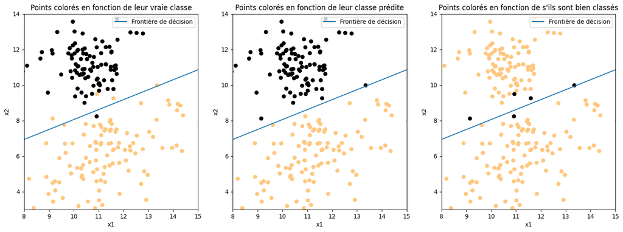

```python
# Plot data points and decision border

_, axs = plt.subplots(1, 3, figsize = (18, 6))
plot_datapoints_decision_border(cmap="true", ax=axs[0])
plot_datapoints_decision_border(cmap="pred", ax=axs[1])
plot_datapoints_decision_border(cmap="true_pred", ax=axs[2])
plt.show()
```

## 1.2 Régression logistique

On rappelle le modèle de régression logistique :

$$ y_i | x_i, \beta \sim \text{B}(g(x_i^\top \beta)), \quad \forall i \in \{1, \ldots, n\}, $$

où $ g : t \rightarrow \frac{1}{1 + \exp(-t)}, \hspace{8px} \forall t \in \mathbb{R} $ est la fonction logistique.

La fonction d'erreur à optimiser (minimiser) est la fonction de vraisemblance négative :

$$ -\mathcal{L}_{(x_i, y_i)_i} (\beta) = -\frac{1}{n} \sum_{i=1}^{n} \left\{ y_i \log g(x_i^\top \beta) + (1 - y_i) \log(1 - g(x_i^\top \beta)) \right\} $$

### a- Donner les valeurs numériques des paramètres appris

```python
# Define sigmoid function


def sigmoid(z):
    return 1 / (1 + np.exp(-z))


# Define cost function for logistic regression
def log_reg_cost_function(params: np.ndarray, X: np.ndarray, y: np.ndarray):
    predictions = sigmoid(np.dot(X, params))
    error = -y * np.log(predictions) - (1 - y) * np.log(1 - predictions)
    cost = (1 / len(y)) * sum(error)
    return cost
```

```python
# Define X and y
X = dataset.loc[:, ["x1", "x2"]]
y = dataset.loc[:, "y"]

# Add bias to X
X = np.c_[np.ones((X.shape[0], 1)), X]

# Init parameters
beta = np.zeros(X.shape[1])

# Optimize cost function
beta_hat = minimize(fun=log_reg_cost_function, x0=beta, args=(X, y))
```

```python
beta_hat = beta_hat.x

# Print parameters of the model
for i, param in enumerate(beta_hat):
    print(f"beta_{i} = {param}")
```

```
beta_0 = 13.430048728509414
beta_1 = 1.8424592405136777
beta_2 = -3.7139987979626263
```

### b- Représenter graphiquement les données sous la forme d’un nuage de points dans $\mathbb{R}^2$ ainsi que la fonction définie pour x∈R2 par l’équation $P(Y=1|X=x)=1/2$

De façon analogue à la partie précédente, de l'analyse linéaire discriminante, nous avons $P(Y=1|X=x) = \frac{1}{2}$

$$\Leftrightarrow 1 + \exp(x^T \beta + \beta_0) = 2 $$$$\Leftrightarrow x_1 \beta_1 + x_2 \beta_2 + \beta_0 = 0 $$$$\Leftrightarrow x_1 = \frac{ - \beta_0 - x_2 \cdot \beta_2 }{ \beta_1 } \hspace{10px} \text{sous réserve que $\beta_1 \ne 0$} $$

Dans cas où $\beta_1 = 0$, la variable $x_1$ n'est simplement pas prise en compte dans le modèle.

```python
# Predict classes
pred_proba = sigmoid(np.dot(X, beta_hat))
y_pred = [proba > 0.5 for proba in pred_proba]
```

```python
# Calculate decision border line
f_xx2 = (-beta_hat[0] - xx2 * beta_hat[2]) / beta_hat[1]
```

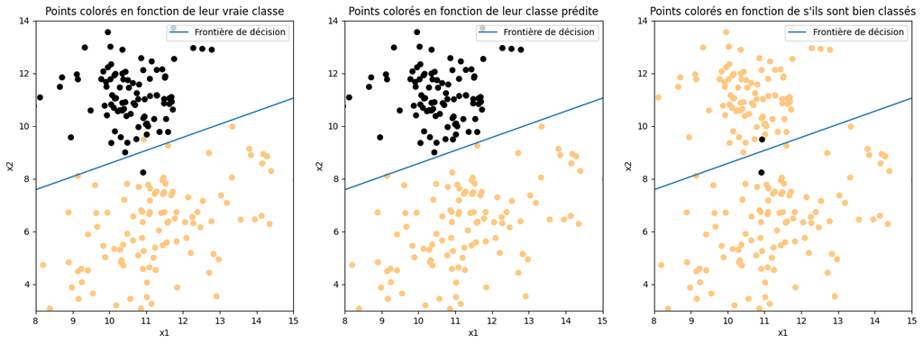

```python
# Plot data points and decision border

_, axs = plt.subplots(1, 3, figsize = (18, 6))
plot_datapoints_decision_border(cmap="true", ax=axs[0])
plot_datapoints_decision_border(cmap="pred", ax=axs[1])
plot_datapoints_decision_border(cmap="true_pred", ax=axs[2])
plt.show()
```

On voit que **la frontière de décision est différente** de celle de l'analyse linéaire discriminante, bien qu'elles soient sensiblement les mêmes.

La régression logistique classe mal seulement deux points alors que l'analyse linéaire discriminante se trompe sur cinq points.

## 1.2 Régression linéaire

Le modèle de régression linéaire multivariée est donné par : $$ y_i = \beta_0 + x_i^\top \beta + \epsilon_i, \quad \forall i \in \{1, \ldots, n\}, $$ où $\epsilon_i $ est i.i.d. selon une distribution normale $ N(0, \sigma^2) $.

L'estimateur du maximum de vraisemblance du vecteur des paramètres de la régression $\beta$ est donné par : $$ \hat{\beta}_{EMV} = (X^\top X)^{-1} X^\top Y. $$

**Dans notre cas, nous considérons $y_i$ comme une variable réelle ne prenant que les valeurs 0 ou 1.**

### a- Donner les valeurs numériques des paramètres appris

```python
# Compute linear regression parameters
beta_hat = np.linalg.inv(X.T @ X) @ X.T @ y

# Print parameters
for i, param in enumerate(beta_hat):
    print(f"beta_{i} = {param}")
```

```
beta_0 = 0.882499841711289
beta_1 = 0.08258172475673495
beta_2 = -0.14757517016760824
```

### b- Représenter graphiquement les données sous la forme d’un nuage de points dans $\mathbb{R}^2$ ainsi que la fonction définie pour x∈R2 par l’équation $P(Y=1|X=x)=1/2$

Afin d'adapter la régression linéaire à notre problème de classification, on adopte la règle suivante : $$y_i = \begin{cases} 0 & \text{si} \hspace{10px} \beta_0 + x_i^\top \beta \leq \frac{1}{2} \\ 1 & \text{si} \hspace{10px} \beta_0 + x_i^\top \beta > \frac{1}{2} \end{cases}$$

Ainsi, la frontière de décision est située sur la droite représentée par l'équation $$\beta_0 + x_i^T \beta = \frac{1}{2} $$ $$\Leftrightarrow x_1 = \frac{ \frac{1}{2} - \beta_0 - x_2 \beta_2 }{ \beta_1 } \hspace{10px} \text{sous réserve que $\beta_1 \ne 0$} $$

```python
# Calculate decision border
f_xx2 = (0.5 - beta_hat[0] - xx2 * beta_hat[2]) / beta_hat[1]
```

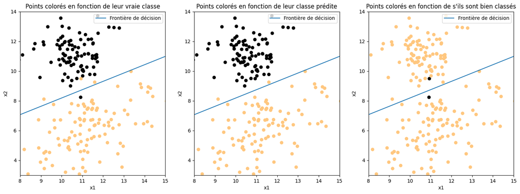

```python
# Plot data points and decision border

_, axs = plt.subplots(1, 3, figsize = (18, 6))
plot_datapoints_decision_border(cmap="true", ax=axs[0])
plot_datapoints_decision_border(cmap="pred", ax=axs[1])
plot_datapoints_decision_border(cmap="true_pred", ax=axs[2])
plt.show()
```

## 4. Réseau de neurones

Implémenter un classifieur pour ce problème à l'aide de PyTorch (obligatoirement). Le classifieur doit être un réseau de neurones à 5 couches cachées. Chaque couche cachée $ j $ doit avoir $ 10 - j $ neurones. Ainsi, la première couche cachée doit avoir 9 neurones et la cinquième 5.

```python
# Define neural network


class Classifier(nn.Module):
    def __init__(self):
        super(Classifier, self).__init__()
        self.fc1 = nn.Linear(in_features=2, out_features=9)
        self.fc2 = nn.Linear(9, 8)
        self.fc3 = nn.Linear(8, 7)
        self.fc4 = nn.Linear(7, 6)
        self.fc5 = nn.Linear(6, 5)
        self.fc6 = nn.Linear(5, 1)

    def forward(self, x):
        x = torch.relu(self.fc1(x))
        x = torch.relu(self.fc2(x))
        x = torch.relu(self.fc3(x))
        x = torch.relu(self.fc4(x))
        x = torch.relu(self.fc5(x))
        x = torch.sigmoid(self.fc6(x))
        return x
```

```python
# Reshape y for tensorflow
y = np.array(y).reshape(-1, 1)

# Define X
X = dataset.loc[:, ["x1", "x2"]].to_numpy()

# Convert data to PyTorch tensors
X_tensor = torch.Tensor(X)
y_tensor = torch.Tensor(y)
```

```python
# Create model
model = Classifier()

# Define loss function and optimizer
criterion = nn.BCELoss()
optimizer = optim.Adam(model.parameters(), lr=0.01)
```

```python
# Train model
num_epochs = 100
for epoch in range(num_epochs):
    # Make forward pass
    outputs = model.forward(X_tensor)
    loss = criterion.forward(outputs, y_tensor)

    # Make backward pass and optimization
    optimizer.zero_grad()
    loss.backward()
    optimizer.step()

    if (epoch + 1) % 100 == 0:
        print("Epoch [{}/{}], Loss: {:.4f}".format(epoch + 1, num_epochs, loss.item()))
```

```
Epoch [100/100], Loss: 0.0427
```

### a- Donner les valeurs numériques des paramètres appris

```python
# Display parameters
for name, param in model.named_parameters():
    print(name, param.data)
```

```
fc1.weight tensor([[-0.0431,  0.0022],
        [-0.1331, -0.3574],
        [-0.2290,  0.9349],
        [ 0.8821,  0.4081],
        [-0.1393, -0.5791],
        [ 0.8331,  0.3658],
        [ 0.4660, -0.2893],
        [ 0.0173,  0.6066],
        [-0.7058, -0.1294]])
fc1.bias tensor([-0.5606,  0.6997, -0.0069,  0.3215,  0.0963,  1.0476,  0.4072, -1.1130,
        -0.6496])
fc2.weight tensor([[ 0.1229,  0.0294, -0.3112,  0.0536, -0.1020, -0.1665,  0.0193, -0.2530,
         -0.0956],
        [-0.1851,  0.1801, -0.2653, -0.1937, -0.1637,  0.0242,  0.0645,  0.1759,
         -0.1728],
        [-0.1163,  0.0519,  0.2950,  0.0300,  0.2977,  0.4297, -0.2564,  0.6259,
         -0.1417],
        [ 0.2736, -0.0888,  0.0016,  0.5469, -0.2183,  0.5938,  0.3853, -0.1385,
          0.0682],
        [-0.1787, -0.1241, -0.5395,  0.1578, -0.2551,  0.3475,  0.5558, -0.3791,
         -0.0431],
        [-0.0833,  0.0475, -0.2720, -0.0025, -0.0965,  0.2613,  0.4340, -0.2677,
          0.3064],
        [ 0.1644, -0.1733, -0.1398, -0.2592, -0.3274, -0.2966, -0.2137, -0.1087,
         -0.2572],
        [-0.0019,  0.1100,  0.2614, -0.0825, -0.1143, -0.2704, -0.3126, -0.1002,
          0.2075]])
fc2.bias tensor([-0.0155, -0.1323, -0.3965,  0.3898,  0.1839,  0.5897, -0.2747,  0.2610])
fc3.weight tensor([[ 0.2449, -0.1255, -0.1965, -0.1657, -0.2390,  0.0853, -0.2913,  0.1207],
        [ 0.1130, -0.3515,  0.5824,  0.4064, -0.3583, -0.2665, -0.1788, -0.2167],
        [-0.2049,  0.0673,  0.2928,  0.5746,  0.2666,  0.5333, -0.3202,  0.1801],
        [-0.0675,  0.0166, -0.5801,  0.5029,  0.4236,  0.6835, -0.2561,  0.0522],
        [-0.1062,  0.2871,  0.2581,  0.3576, -0.3886, -0.4196,  0.1829,  0.2772],
        [-0.0432, -0.3077, -0.0823, -0.3477, -0.1722, -0.2197, -0.3305,  0.3185],
        [-0.1978,  0.0215, -0.0470,  0.7578,  0.5013,  0.0567,  0.2977, -0.2377]])
fc3.bias tensor([-0.3238,  0.1787, -0.0263,  0.5564,  0.2098,  0.2706,  0.3294])
fc4.weight tensor([[-0.2116,  0.6135,  0.3153, -0.4737,  0.7480,  0.1487,  0.2878],
        [-0.0699, -0.5090,  0.4653,  0.6714, -0.3228,  0.2547,  0.3902],
        [ 0.2974,  0.1181,  0.0878,  0.4828, -0.3428, -0.1741,  0.6100],
        [-0.0257, -0.3143, -0.2461, -0.2114, -0.0578, -0.0625,  0.0467],
        [-0.1734, -0.1825,  0.6059,  0.4925, -0.3172,  0.3178,  0.1320],
        [-0.1404, -0.0973, -0.1412, -0.0983, -0.0449, -0.0664,  0.0900]])
fc4.bias tensor([ 0.2328,  0.3634,  0.1660, -0.2514,  0.2378, -0.3658])
fc5.weight tensor([[ 0.3780,  0.0622,  0.2448, -0.1081,  0.0526, -0.3956],
        [-0.3468,  0.2852,  0.7629, -0.3515,  0.3137, -0.2424],
        [ 0.7375, -0.4230,  0.1267,  0.2451,  0.2913, -0.1506],
        [-0.0123, -0.2733, -0.3413,  0.0766, -0.4648,  0.1452],
        [-0.2712,  0.5516,  0.4156, -0.1210,  0.4426, -0.1012]])
fc5.bias tensor([-0.1677,  0.4208,  0.3059, -0.4549,  0.1853])
fc6.weight tensor([[-0.6164,  0.5599, -0.5285,  0.0764,  0.7431]])
fc6.bias tensor([-0.3357])
```

### b- Représenter graphiquement les données sous la forme d’un nuage de points dans $\mathbb{R}^2$ ainsi que la fonction définie pour x∈R2 par l’équation $P(Y=1|X=x)=1/2$

```python
# Prepare meshgrid for displaying decision border
x_min, x_max = X[:, 0].min() - 1, X[:, 0].max() + 1
y_min, y_max = X[:, 1].min() - 1, X[:, 1].max() + 1
xx, yy = np.meshgrid(np.arange(x_min, x_max, 0.1), np.arange(y_min, y_max, 0.1))
xx.shape
```

```
(142, 95)
```

```python
# Transform meshgrid into data points
datapoints_grid = np.c_[xx.ravel(), yy.ravel()]

# Transform datapoints into torch tensor
datapoints_grid = torch.Tensor(datapoints_grid)
datapoints_grid.shape
```

```
torch.Size([13490, 2])
```

```python
# Predict grid to plot decision border
y_pred_grid = model.forward(datapoints_grid).detach().numpy()

# Reshape predictions into grid shape
y_pred_grid = y_pred_grid.reshape(xx.shape)
y_pred_grid.shape
```

```
(142, 95)
```

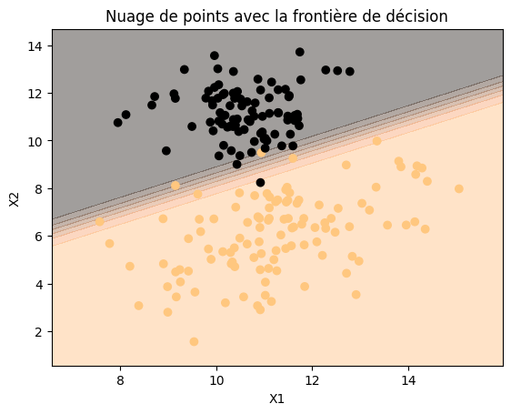

```python
# Plot datapoints and decision border
plt.contourf(xx, yy, y_pred_grid, alpha=0.4, cmap="copper")
plt.scatter(X[:, 0], X[:, 1], c=y, cmap="copper")
plt.xlabel("X1")
plt.ylabel("X2")
plt.title("Nuage de points avec la frontière de décision")
plt.show()
```

## 5. Application

Les données des fichiers testA, testB et testC sont respectivement tirées de la même distribution que les données des fichiers trainA, trainB et trainC. Tester les différents modèles appris à partir des données d’apprentissage correspondantes sur ces données de test.

### a- Calculer pour chaque modèle l’erreur de classification (c’est-à-dire la fraction des données mal classées) sur les données d’apprentissage et calculer-la également sur les données de test.

```python
class LogisticRegression:
    def __init__(self) -> None:
        pass

    def fit(self, X: np.ndarray, y: np.ndarray) -> None:
        # Add bias to X
        X = np.c_[np.ones((X.shape[0], 1)), X]

        # Init parameters
        beta = np.zeros(X.shape[1])

        # Optimize cost function
        beta_hat = minimize(fun=log_reg_cost_function, x0=beta, args=(X, y))

        # Retrieve array of values
        self.beta_hat = beta_hat.x

        return self.beta_hat

    def predict(self, X: np.ndarray):
        """Make prediction for logistic regression with two dimensional data

        Args:
            X (np.ndarray): Dataset + column of ones for bias

        Returns:
            tuple: predictions and predicted proba
        """
        # Retrieve parameters
        params = self.beta_hat

        # Add bias to X
        X = np.c_[np.ones((X.shape[0], 1)), X]

        linear_reg_part = X @ params
        y_pred_proba = sigmoid(linear_reg_part)
        y_pred = [proba > 0.5 for proba in y_pred_proba]

        return y_pred, y_pred_proba
```

```python
class LinearRegression:
    def __init__(self) -> None:
        pass

    def fit(self, X: np.ndarray, y: np.ndarray) -> None:
        # Add bias to X
        X = np.c_[np.ones((X.shape[0], 1)), X]

        # Compute linear regression parameters
        self.beta_hat = np.linalg.inv(X.T @ X) @ X.T @ y

        return self.beta_hat

    def predict(self, X: np.ndarray):
        """Make prediction for linear regression with two dimensional data

        Args:
            X (np.ndarray): Dataset + column of ones for bias
            params (np.ndarray): Array of parameters (beta0, beta1, beta2)

        Returns:
            tuple: predictions and predicted proba
        """
        # Retrieve parameters
        params = self.beta_hat

        # Add bias to X
        X = np.c_[np.ones((X.shape[0], 1)), X]

        y_pred_proba = X @ params
        y_pred = [proba > 0.5 for proba in y_pred_proba]

        return y_pred, y_pred_proba
```

```python
class LinearDiscriminantAnalysis:
    def __init__(self) -> None:
        pass

    def fit(self, X: np.ndarray, y: np.ndarray) -> None:
        # Adapt data to MLE calculation function
        df = pd.DataFrame({"x1": X[:, 0], "x2": X[:, 1], "y": y})

        # Make calculus
        self.pi = calc_pi_mle(df)
        self.mu0, self.mu1 = calc_mu_mle(df)
        self.sigma = calc_sigma_mle(df, self.mu0, self.mu1)
        self.params = (self.pi, self.mu0, self.mu1, self.sigma)

        return self.pi, self.mu0, self.mu1, self.sigma

    def predict(self, X: np.ndarray) -> tuple:
        """Make prediction for linear discriminant analysis

        Args:
            X (np.ndarray): Two dimensional dataset

        Returns:
            tuple: predictions and predicted proba
        """
        # Retrieve parameters
        pi, mu0, mu1, Sigma = self.params
        Sigma_inv = np.linalg.inv(Sigma)

        # Calculate proba

        # Iterate over row i.e. data points
        exponential_part = np.zeros(X.shape[0])
        for i in range(X.shape[0]):
            exponential_part[i] = 0.5 * (
                (X[i] - mu0) @ Sigma_inv @ (X[i] - mu0).T
                - (X[i] - mu1) @ Sigma_inv @ (X[i] - mu1).T
            )

        denominateur = 1 + ((1 - pi) / pi) * np.exp(exponential_part)

        y_pred_proba = 1 / denominateur

        y_pred = [
            proba < 0.5 for proba in y_pred_proba
        ]  # I don't know why I must take proba < 0.5 and not > 0.5

        return y_pred, y_pred_proba
```

```python
class NeuralNetwork:
    def __init__(self) -> None:
        pass

    def fit(self, X: np.ndarray, y: np.ndarray, num_epochs: int = 100) -> None:
        # Convert data to PyTorch tensors
        X_tensor = torch.Tensor(X)
        y_tensor = torch.Tensor(y.reshape(-1, 1))

        # Create model
        self.model = Classifier()

        # Define loss function and optimizer
        criterion = nn.BCELoss()
        optimizer = optim.Adam(self.model.parameters(), lr=0.01)

        # Train model
        for _ in range(num_epochs):
            # Make forward pass
            outputs = self.model.forward(X_tensor)
            loss = criterion.forward(outputs, y_tensor)

            # Make backward pass and optimization
            optimizer.zero_grad()
            loss.backward()
            optimizer.step()

    def predict(self, X: np.ndarray) -> tuple:
        """Make prediction for neural network

        Args:
            X (np.ndarray): Two dimensional dataset

        Returns:
            tuple: predictions and predicted proba
        """
        X_tensor = torch.Tensor(X)

        y_pred_proba = self.model.forward(X_tensor).detach().numpy()

        y_pred = [
            proba > 0.5 for proba in y_pred_proba
        ]  # I don't know why I must take proba < 0.5 and not > 0.5

        return y_pred, y_pred_proba
```

```python
# Create dictionnary to store datasets summary
results = {}

# Iterate over datasets
for dataset_index in ["A", "B", "C"]:
    # Define train test split
    X_train, X_test = (
        train[dataset_index].loc[:, ["x1", "x2"]].to_numpy(),
        test[dataset_index].loc[:, ["x1", "x2"]].to_numpy(),
    )
    y_train, y_test = (
        train[dataset_index].loc[:, "y"].to_numpy(),
        test[dataset_index].loc[:, "y"].to_numpy(),
    )

    # Init results storage
    results[dataset_index] = []

    # Iterate over models
    for model in [
        LinearDiscriminantAnalysis(),
        LinearRegression(),
        LogisticRegression(),
        NeuralNetwork(),
    ]:
        model.fit(X_train, y_train)
        y_train_pred, _ = model.predict(X_train)
        y_test_pred, _ = model.predict(X_test)
        train_accuracy = sum(
            1 for true, pred in zip(y_train_pred, y_train) if true == pred
        ) / len(y_train)
        test_accuracy = sum(
            1 for true, pred in zip(y_test, y_test_pred) if true == pred
        ) / len(y_test)
        # Append result
        results[dataset_index].append(
            {
                "Model": type(model).__name__,
                "Train Accuracy": train_accuracy,
                "Test Accuracy": test_accuracy,
            }
        )

    results[dataset_index] = pd.DataFrame(results[dataset_index])
```

**Dataset A**

```python
results["A"]
```

|  | Model | Train Accuracy | Test Accuracy |
| --- | --- | --- | --- |
| 0 | LinearDiscriminantAnalysis | 1.0 | 0.99 |
| 1 | LinearRegression | 1.0 | 0.99 |
| 2 | LogisticRegression | 1.0 | 0.98 |
| 3 | NeuralNetwork | 1.0 | 0.98 |

**Dataset B**

```python
results["B"]
```

|  | Model | Train Accuracy | Test Accuracy |
| --- | --- | --- | --- |
| 0 | LinearDiscriminantAnalysis | 0.975 | 0.950 |
| 1 | LinearRegression | 0.980 | 0.955 |
| 2 | LogisticRegression | 0.990 | 0.965 |
| 3 | NeuralNetwork | 0.985 | 0.960 |

**Dataset C**

```python
results["C"]
```

|  | Model | Train Accuracy | Test Accuracy |
| --- | --- | --- | --- |
| 0 | LinearDiscriminantAnalysis | 0.973333 | 0.966667 |
| 1 | LinearRegression | 0.973333 | 0.960000 |
| 2 | LogisticRegression | 0.970000 | 0.953333 |
| 3 | NeuralNetwork | 0.966667 | 0.963333 |

### b- Comparer les performances des différentes méthodes sur les trois jeux de données.

L’erreur de classification est-elle plus grande, plus petite ou similaire sur les données d’entraînement et de test ? Pourquoi ?

Quelles méthodes donnent des résultats très similaires/différents ?

Quelles méthodes donnent les meilleurs résultats sur les différents jeux de données ?

Donner une interprétation.

**Accuracy sur les données d'entraînement / de test :**

L'*accuracy* - la justesse de prédiction - pour tous nos modèles et sur tous nos jeux de données, est supérieure pour les données d'entraînement.

Cela était attendu car le modèle s'ajuste sur les données d'entraînement, il apprend sur celles-ci, alors qu'il n'a pas connaissance des *labels* des données de test.

La métrique qui nous importe le plus pour sélectionner un modèle de prédiction est l'*accuracy* de test. En effet, c'est elle qui donne une idée du pouvoir de généralisation du modèle.

Si l'on voulait un modèle uniquement descriptif, on pourrait ne pas faire de *train test split*, et choisir le modèle avec le meilleur score (par exemple pour l'explication d'un phénomène en économétrie).

**Comparaisons des différentes méthodes :**

Toutes les méthodes donnent des résultats très similaires.  
Les *accuracy* de test varient entre 95 et 99%:

| Dataset | Meilleur modèle | Justesse de prédiction (%) |
| --- | --- | --- |
| A | Analyse linéaire discriminante | 99 |
| B | Régression logistique | 96.5 |
| C | Analyse linéaire discriminante | 96.7 |

On pouvait s'attendre à ce que le **réseau de neurone** ne fasse pas mieux car les données sont simples et bien séparables. Il **performerait relativement mieux sur des données plus complexes** (grande dimension, texte, cours boursier etc.)

# 2- Modèle de mélange Gaussien et algorithme EM

Dans cette partie, nous allons analyser le jeu de données *decathlon* des performances sportives de 41 athlètes.

```python
# Rename index column
decathlon.rename_axis("name", inplace=True)
```

```python
# Print head of dataframe
decathlon.head()
```

| name | 100m | Long.jump | Shot.put | High.jump | 400m | 110m.hurdle | Discus | Pole.vault | Javeline | 1500m |
| --- | --- | --- | --- | --- | --- | --- | --- | --- | --- | --- |
| SEBRLE | 11.04 | 7.58 | 14.83 | 2.07 | 49.81 | 14.69 | 43.75 | 5.02 | 63.19 | 291.7 |
| CLAY | 10.76 | 7.40 | 14.26 | 1.86 | 49.37 | 14.05 | 50.72 | 4.92 | 60.15 | 301.5 |
| KARPOV | 11.02 | 7.30 | 14.77 | 2.04 | 48.37 | 14.09 | 48.95 | 4.92 | 50.31 | 300.2 |
| BERNARD | 11.02 | 7.23 | 14.25 | 1.92 | 48.93 | 14.99 | 40.87 | 5.32 | 62.77 | 280.1 |
| YURKOV | 11.34 | 7.09 | 15.19 | 2.10 | 50.42 | 15.31 | 46.26 | 4.72 | 63.44 | 276.4 |

```python
print(f"Nombre d'athlètes : {decathlon.index.nunique()}")
print(f"Nombre de lignes dans le jeu de données : {len(decathlon)}")
```

```
Nombre d'athlètes : 41
Nombre de lignes dans le jeu de données : 41
```

Chaque athlète apparaît une seule fois dans le jeu de données.

```python
# Display statistical summary of dataset
decathlon.describe()
```

|  | 100m | Long.jump | Shot.put | High.jump | 400m | 110m.hurdle | Discus | Pole.vault | Javeline | 1500m |
| --- | --- | --- | --- | --- | --- | --- | --- | --- | --- | --- |
| count | 41.000000 | 41.000000 | 41.000000 | 41.000000 | 41.000000 | 41.000000 | 41.000000 | 41.000000 | 41.000000 | 41.000000 |
| mean | 10.998049 | 7.260000 | 14.477073 | 1.976829 | 49.616341 | 14.605854 | 44.325610 | 4.762439 | 58.316585 | 279.024878 |
| std | 0.263023 | 0.316402 | 0.824428 | 0.088951 | 1.153451 | 0.471789 | 3.377845 | 0.278000 | 4.826820 | 11.673247 |
| min | 10.440000 | 6.610000 | 12.680000 | 1.850000 | 46.810000 | 13.970000 | 37.920000 | 4.200000 | 50.310000 | 262.100000 |
| 25% | 10.850000 | 7.030000 | 13.880000 | 1.920000 | 48.930000 | 14.210000 | 41.900000 | 4.500000 | 55.270000 | 271.020000 |
| 50% | 10.980000 | 7.300000 | 14.570000 | 1.950000 | 49.400000 | 14.480000 | 44.410000 | 4.800000 | 58.360000 | 278.050000 |
| 75% | 11.140000 | 7.480000 | 14.970000 | 2.040000 | 50.300000 | 14.980000 | 46.070000 | 4.920000 | 60.890000 | 285.100000 |
| max | 11.640000 | 7.960000 | 16.360000 | 2.150000 | 53.200000 | 15.670000 | 51.650000 | 5.400000 | 70.520000 | 317.000000 |

## Détermination du nombre de clusters

Regardons les scores BIC et silhouette en fonction du nombre de clusters.

Le score de silhouette calcule à quel point un objet est similaire à son propre groupe (cohésion) par rapport aux autres groupes (séparation). Il est défini comme suit :

Silhouette score = $\frac{1}{N} \sum_{i=1}^{N} \frac{b_i - a_i}{\max(a_i, b_i)}$

Où :

- $N$ est le nombre d'individus
- $a_i$ est la distance moyenne du ième point de données aux autres points dans son groupe
- $b_i$ est distance moyenne du ième point de données à l'autre groupe le plus proche

```python
silhouette_list = []
bic_list = []

n_cluster_min = 2
n_cluster_max = 10

for n in range(n_cluster_min, n_cluster_max + 1):
    # Define model
    gmm = GaussianMixture(
        covariance_type="full", n_components=n, init_params="kmeans", n_init=100
    )
    # Fit model
    gmm.fit(decathlon)
    # Get clusters
    cluster_vector = gmm.predict(decathlon)
    # Calculate scores
    silhouette_score_ = silhouette_score(decathlon, cluster_vector)
    bic = gmm.bic(decathlon)
    # Save scores
    silhouette_list.append(silhouette_score_)
    bic_list.append(bic)
```

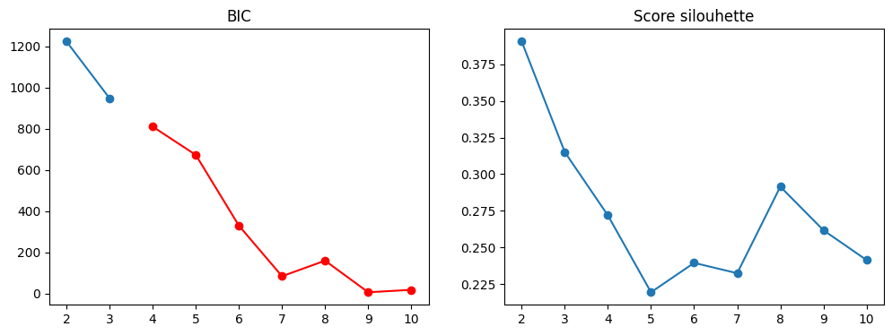

```python
_, axs = plt.subplots(1, 2, figsize=(12, 4))
axs[0].plot(range(n_cluster_min, 4), bic_list[:2], "o-")
axs[0].plot(range(4, n_cluster_max + 1), bic_list[2: n_cluster_max + 1], "o-", color="red")
axs[0].set_xticks(range(n_cluster_min, n_cluster_max + 1))
axs[0].set_title("BIC")

axs[1].plot(range(n_cluster_min, n_cluster_max + 1), silhouette_list, "o-")
axs[1].set_xticks(range(n_cluster_min, n_cluster_max + 1))
axs[1].set_title("Score silouhette")
```

Le score BIC n'est pas à prendre en compte à partir d'un trop grand nombre de clusters et avec un *dataset* à 41 entrées.  
En effet, avec des matrices de variance-covariance libres à estimer, le nombre de paramètres à estimer devient rapidement très supérieur au nombre d'individus.

Nous prendrons, en raison de la taille du jeu de données et des contraintes de l'énoncé, 3 clusters pour la suite de l'étude.

## K = 3 clusters

```python
# Fit GMM with 3 clusters

gmm = GaussianMixture(
    covariance_type="full", n_components=3, init_params="k-means++", n_init=1_000
)

gmm.fit(decathlon)
predicted_cluster = gmm.predict(decathlon)
```

### Affichage des poids

```python
weights_df = pd.DataFrame(gmm.weights_, columns=[''], index=[f'Poids {i}' for i in range(len(gmm.weights_))])
weights_df
```

| Poids 0 | 0.121951 |
| --- | --- |
| Poids 1 | 0.731707 |
| Poids 2 | 0.146341 |

### Visualisation des clusters

Réalisons une réduction de dimension en 2D sur nos données afin de visualiser les clusters sur un graphique.

```python
# Make PCA
pca = PCA(n_components=2)
pca.fit(decathlon)
```

```
PCA(n_components=2)
```

```python
print(f"Le premier axe explique {round(pca.explained_variance_ratio_[0]* 100, 1) }% des données.")
print(f"Le deuxième axe explique {round(pca.explained_variance_ratio_[1] * 100, 1)}% des données.")
print(f"Notre réduction de dimension conserve donc {round((pca.explained_variance_ratio_[0] + pca.explained_variance_ratio_[1]) * 100, 1)}% de l'information.")
```

```
Le premier axe explique 79.7% des données.
Le deuxième axe explique 13.6% des données.
Notre réduction de dimension conserve donc 93.2% de l'information.
```

```python
# Calculate centers of clusters
mu = pd.DataFrame(gmm.means_)
mu.columns = decathlon.columns
```

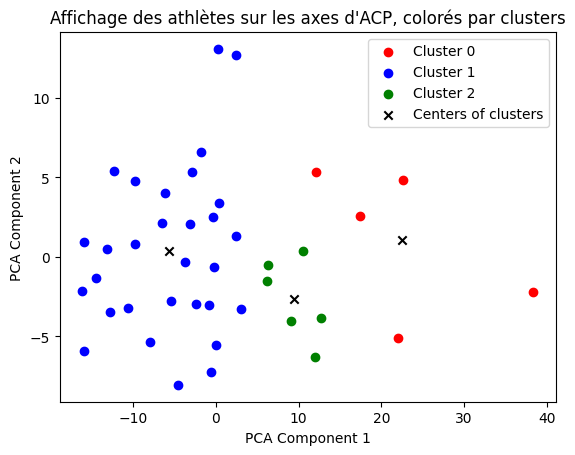

```python
# Filter the data for clusters 0, 1, and 2
cluster_0_indices = predicted_cluster == 0
cluster_1_indices = predicted_cluster == 1
cluster_2_indices = predicted_cluster == 2

# Plot only the points belonging to clusters 0, 1, and 2
plt.scatter(pca.transform(decathlon)[:, 0][cluster_0_indices], pca.transform(decathlon)[:, 1][cluster_0_indices], c='r', label='Cluster 0')
plt.scatter(pca.transform(decathlon)[:, 0][cluster_1_indices], pca.transform(decathlon)[:, 1][cluster_1_indices], c='b', label='Cluster 1')
plt.scatter(pca.transform(decathlon)[:, 0][cluster_2_indices], pca.transform(decathlon)[:, 1][cluster_2_indices], c='g', label='Cluster 2')

# Plot centers of clusters
plt.scatter(*pca.transform(mu).T, marker="x", color="black", label="Centers of clusters")

# Add labels and legend
plt.xlabel('PCA Component 1')
plt.ylabel('PCA Component 2')
plt.title("Affichage des athlètes sur les axes d'ACP, colorés par clusters")
plt.legend()

plt.show()
```

Le clustering semble correctement isoler trois groupes. En effet les centres de gravité de chacun des clusters sont bien séparés.

Il y a deux groupes relativement petits et un grand groupes, le cluster 1, en bleu.

```python
score_to_minimize = [1, 0, 0, 0, 1, 1, 0, 0, 0, 1] # Running sports
score_to_maximize = [1 - score for score in score_to_minimize]
```

```python
# Display clusters centers

# Define a function to apply styling
def highlight_max(s):
    """
    Highlight the maximum in a Series yellow.
    """
    is_max = s == s.max()
    return ['background-color: lime' if v else '' for v in is_max]

def highlight_min(s):
    """
    Highlight the minimum in a Series yellow.
    """
    is_min = s == s.min()
    return ['background-color: yellow' if v else '' for v in is_min]

# Apply styling to the DataFrame
styled_df = mu.style.apply(highlight_max).apply(highlight_min)

print("Moyenne des scores des athlètes par cluster pour chaque discipline :\nEn vert les plus haut, en jaune les faibles.\nOn prendra en compte que certaines épreuves requièrent un score faible.")

# Display the styled DataFrame
styled_df
```

```
Moyenne des scores des athlètes par cluster pour chaque discipline :
En vert les plus haut, en jaune les faibles.
On prendra en compte que certaines épreuves requièrent un score faible.
```

|  | 100m | Long.jump | Shot.put | High.jump | 400m | 110m.hurdle | Discus | Pole.vault | Javeline | 1500m |
| --- | --- | --- | --- | --- | --- | --- | --- | --- | --- | --- |
| 0 | 11.008000 | 7.206000 | 14.718000 | 1.970000 | 50.382000 | 14.636000 | 47.630000 | 4.792000 | 57.064000 | 301.304000 |
| 1 | 10.979000 | 7.293333 | 14.482333 | 1.977333 | 49.272333 | 14.565333 | 43.975333 | 4.731333 | 59.133667 | 273.453333 |
| 2 | 11.085000 | 7.138333 | 14.250000 | 1.980000 | 50.698333 | 14.783333 | 43.323333 | 4.893333 | 55.275000 | 288.316667 |

### Interprétation des clusters

Le cluster 1 rassemble les meilleurs athlètes pour les épreuves de rapidité : 100m, 400m, 1500m et 110m haies. Mais aussi en épreuves techniques : lancé de javelot, saut en longueur.

Le cluster 0 rassemble les athlètes moyens dans la majorité des catégories.